# Cardio Good Fitness Dataset

- Data Features:
- Product - the model no. of the treadmill
- Age - in no of years, of the customer
- Gender - of the customer
- Education - in no. of years, of the customer
- Marital Status - of the customer
- Usage - Avg. # times the customer wants to use the treadmill every week
- Fitness - Self rated fitness score of the customer (5 - very fit, 1 - very unfit)
- Income - of the customer
- Miles- expected to run

### Loading the Libraries

```python
import warnings
warnings.filterwarnings('ignore')   # Avoid warnings which may occur

import numpy as np                  # Importing Numerical python library for scirntific computing
import pandas as pd                 # Importing Pandas library for data manipulation and analysis
import seaborn as sns               # Seaborn is a Python data visualization library based on matplotlib
import matplotlib.pyplot as plt
sns.set(color_codes=True)
%matplotlib inline
```

### Import the dataset(CardioGoodFitness)

```python
cardio = pd.read_csv('CardioGoodFitness.csv'); # Import the datset named 'CardioGoodFitness.csv'
```

### View different Dataset Characterisitics

```python
cardio.head(5) # View the first 5 rows of the data
```

|  | Product | Age | Gender | Education | MaritalStatus | Usage | Fitness | Income | Miles |
| --- | --- | --- | --- | --- | --- | --- | --- | --- | --- |
| 0 | TM195 | 18 | Male | 14 | Single | 3 | 4 | 29562 | 112 |
| 1 | TM195 | 19 | Male | 15 | Single | 2 | 3 | 31836 | 75 |
| 2 | TM195 | 19 | Female | 14 | Partnered | 4 | 3 | 30699 | 66 |
| 3 | TM195 | 19 | Male | 12 | Single | 3 | 3 | 32973 | 85 |
| 4 | TM195 | 20 | Male | 13 | Partnered | 4 | 2 | 35247 | 47 |

###### Observations:

- Product contains the model no. of treadmill
- Age, Education, Usage, Fitness, Income, Miles variables are numerical
- Product, Gender, MaritalStatus variables are categorical

```python
cardio.info(); # This .info will give information on each of the variable and number of values entered in each variable
```

```
<class 'pandas.core.frame.DataFrame'>
RangeIndex: 180 entries, 0 to 179
Data columns (total 9 columns):
 #   Column         Non-Null Count  Dtype
---  ------         --------------  -----
 0   Product        180 non-null    object
 1   Age            180 non-null    int64
 2   Gender         180 non-null    object
 3   Education      180 non-null    int64
 4   MaritalStatus  180 non-null    object
 5   Usage          180 non-null    int64
 6   Fitness        180 non-null    int64
 7   Income         180 non-null    int64
 8   Miles          180 non-null    int64
dtypes: int64(6), object(3)
memory usage: 12.8+ KB
```

###### Observations:

- All columns have 180 observations which means there are no missing values
- Product is read as object but it should have data type - modelno.

```python
## In order to see the Dimension of Data following code is used

cardio.shape
```

```
(180, 9)
```

###### Observations:

- There are 180 observations/Rows and 9 Attributes/Columns

```python
len(cardio) # len() is a built-in function which will give the number of elements from the cardio fitness dataset
```

```
180
```

### EDA Descriptive Statistics

```python
cardio.describe(include='all') #  The describe method for calculating statistical data viz.
                               # count, Unique, top, freq, mean, std, min, 25%, 50%, 75%, max
```

|  | Product | Age | Gender | Education | MaritalStatus | Usage | Fitness | Income | Miles |
| --- | --- | --- | --- | --- | --- | --- | --- | --- | --- |
| count | 180 | 180.000000 | 180 | 180.000000 | 180 | 180.000000 | 180.000000 | 180.000000 | 180.000000 |
| unique | 3 | NaN | 2 | NaN | 2 | NaN | NaN | NaN | NaN |
| top | TM195 | NaN | Male | NaN | Partnered | NaN | NaN | NaN | NaN |
| freq | 80 | NaN | 104 | NaN | 107 | NaN | NaN | NaN | NaN |
| mean | NaN | 28.788889 | NaN | 15.572222 | NaN | 3.455556 | 3.311111 | 53719.577778 | 103.194444 |
| std | NaN | 6.943498 | NaN | 1.617055 | NaN | 1.084797 | 0.958869 | 16506.684226 | 51.863605 |
| min | NaN | 18.000000 | NaN | 12.000000 | NaN | 2.000000 | 1.000000 | 29562.000000 | 21.000000 |
| 25% | NaN | 24.000000 | NaN | 14.000000 | NaN | 3.000000 | 3.000000 | 44058.750000 | 66.000000 |
| 50% | NaN | 26.000000 | NaN | 16.000000 | NaN | 3.000000 | 3.000000 | 50596.500000 | 94.000000 |
| 75% | NaN | 33.000000 | NaN | 16.000000 | NaN | 4.000000 | 4.000000 | 58668.000000 | 114.750000 |
| max | NaN | 50.000000 | NaN | 21.000000 | NaN | 7.000000 | 5.000000 | 104581.000000 | 360.000000 |

###### Observations:

- There are 3 types of products in the dataset
- Mean Age of Customer is 29 years and most of the Customers Age are distributed between 24 to 33 years
- Mean Miles run by Customers is 103 with 360 Miles maximum run by Customers
- Maxiumum Customer Income is around $104K
- Top Selling Product is TM195

##### Plotting the summary mean,mode,median using histogram for Miles Variable

```
Mean:  103.19444444444444
Median:  94.0
Mode:  85
```

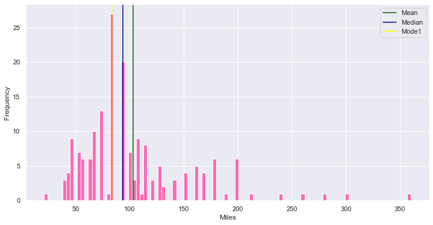

```python
mean=cardio['Miles'].mean()
median=cardio['Miles'].median()
mode=cardio['Miles'].mode()

print('Mean: ',mean,'\nMedian: ',median,'\nMode: ',mode[0]) # Printing the Mean, Median, Mode values with label

plt.figure(figsize=(12,6)) # Figure size is set
plt.hist(cardio['Miles'],bins=100,color='hotpink') #Histogram is plotted

plt.axvline(mean,color='darkgreen',label='Mean')
plt.axvline(median,color='darkblue',label='Median')
plt.axvline(mode[0],color='yellow',label='Mode1')

plt.xlabel('Miles')   # labelling x-axis
plt.ylabel('Frequency')   # labelling y-axis
plt.legend()              # Plotting the legend
plt.show()
```

###### Observations:

Distribution is Positively Skewed since Mean > Median > Mode

###### Determining the most sold model

```python
cardio.Product.value_counts()
```

```
TM195    80
TM498    60
TM798    40
Name: Product, dtype: int64
```

###### Determining TreadMill Sale by Gender

```python
cardio.Gender.value_counts()
```

```
Male      104
Female     76
Name: Gender, dtype: int64
```

###### Determining Average Age of Customer buying each model

```python
cardio.groupby('Product')['Age'].mean()
```

```
Product
TM195    28.55
TM498    28.90
TM798    29.10
Name: Age, dtype: float64
```

###### Determining Average Income of Customer buying each model

```python
cardio.groupby('Product')['Income'].mean()
```

```
Product
TM195    46418.025
TM498    48973.650
TM798    75441.575
Name: Income, dtype: float64
```

###### Determining Average Miles Run by Customer buying each model

```python
cardio.groupby('Product')['Miles'].mean()
```

```
Product
TM195     82.787500
TM498     87.933333
TM798    166.900000
Name: Miles, dtype: float64
```

## Checking Measures of Dispersion

### IQR

```python
cardio.quantile(0.75)-cardio.quantile(0.25) # Calculation of InterQuantile Range for numerical variables in Cardio dataset
```

```
Age              9.00
Education        2.00
Usage            1.00
Fitness          1.00
Income       14609.25
Miles           48.75
dtype: float64
```

### Variance

```python
print(cardio.var()) # Calculation of Variance for numerical variables in Cardio dataset
```

```
Age          4.821217e+01
Education    2.614867e+00
Usage        1.176785e+00
Fitness      9.194289e-01
Income       2.724706e+08
Miles        2.689833e+03
dtype: float64
```

### CoVariance

```python
cardio.cov() # Calculation of Variance for numerical variables in Cardio dataset
```

|  | Age | Education | Usage | Fitness | Income | Miles |
| --- | --- | --- | --- | --- | --- | --- |
| Age | 48.212166 | 3.149410 | 0.113470 | 0.406828 | 5.884446e+04 | 13.186530 |
| Education | 3.149410 | 2.614867 | 0.693172 | 0.636623 | 1.670472e+04 | 25.770795 |
| Usage | 0.113470 | 0.693172 | 1.176785 | 0.695469 | 9.303043e+03 | 42.709808 |
| Fitness | 0.406828 | 0.636623 | 0.695469 | 0.919429 | 8.467925e+03 | 39.073246 |
| Income | 58844.463439 | 16704.717815 | 9303.042582 | 8467.925388 | 2.724706e+08 | 465265.361887 |
| Miles | 13.186530 | 25.770795 | 42.709808 | 39.073246 | 4.652654e+05 | 2689.833489 |

### Check for any missing values and clean them as some plots will not work in case of missing values

```python
cardio.isnull().sum()
```

```
Product          0
Age              0
Gender           0
Education        0
MaritalStatus    0
Usage            0
Fitness          0
Income           0
Miles            0
dtype: int64
```

###### Observations:

- From the result below, there are no missing values in the Dataset

```python
cardio.skew()
```

```
Age          0.982161
Education    0.622294
Usage        0.739494
Fitness      0.454800
Income       1.291785
Miles        1.724497
dtype: float64
```

## Plotting Univariate Distributions

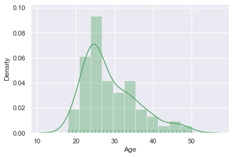

```python
sns.distplot(cardio['Age'], kde=True, rug=True, color='g');
```

###### Observations:

- Age group 24 to 27 has highest density among the available Dataset
- Most of the customers from the Dataset have Age < 35

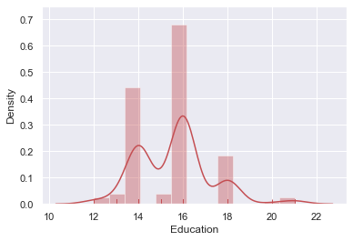

```python
sns.distplot(cardio['Education'], kde=True, rug=True, color='r');
```

###### Observations:

- Major number of customers from the datset have at least 16 years of education
- No customer from the dataset have customers with more than 21 years of education
- The customers have at least 12 years of education

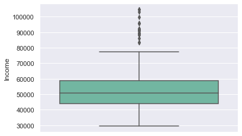

```python
sns.boxplot(y='Income',data=cardio, palette='Set2', linewidth=1.5);
plt.show()
```

###### Observations:

- The median income of customers from the dataset is just above 50000
- Most of the customers have income from 45000 to 60000

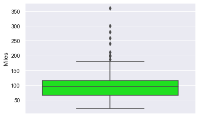

```python
sns.boxplot(y='Miles',data=cardio, color='lime');
plt.show()
```

###### Observations:

- Median number of customers are expected to run around 100 miles
- Major part of customers will run around 60 to 120 miles

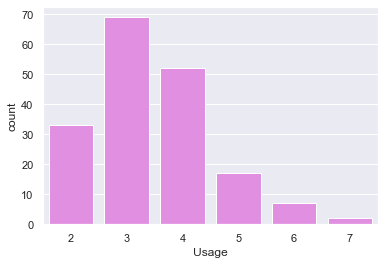

```python
sns.countplot(cardio['Usage'], color='violet');
```

###### Observations:

- Customers mostly use the treadmill 3-4 times a week
- Very few customers use the tradmill 6-7 times a week

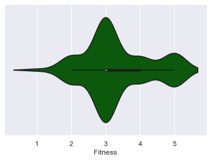

```python
sns.violinplot(cardio['Fitness'], color='darkgreen');
```

###### Observations:

- Most of the Customers have given Fitness Self-Rating as '3'
- Very Few number of Customers have given Self-Rating as '1'(very-unfit)

```
[Text(0.5, 1.0, 'MARTIAL STATUS BY GENDER')]
```

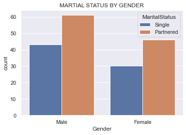

```python
sns.set_theme(style="darkgrid")
sns.countplot(cardio['Gender'], hue=cardio['MaritalStatus']).set(title='MARTIAL STATUS BY GENDER')
```

###### Observations:

- In the dataset, Single or Partnered Male Count is more than Single or Parternered Female Count
- Partnered(either Male or Female) are more compared to Single Male or Female

### Plotting Bivariate Distributions

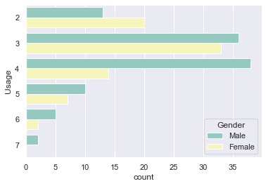

```python
sns.countplot(y='Usage', hue='Gender', data=cardio, palette='Set3');
plt.show()
```

###### Observations:

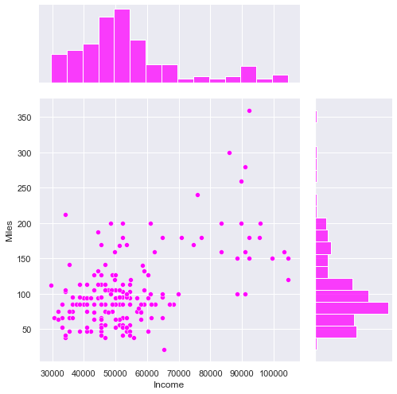

```python
sns.jointplot(data=cardio, x='Income', y='Miles', height=7, ratio=3, color='magenta');
```

###### Observations:

- Most number of Customers have income 30000 to 60000 & are expected to run 40 to 150 miles

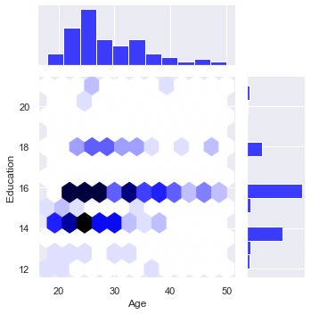

```python
sns.jointplot(data=cardio, x='Age', y='Education', height=5, ratio=3, color='blue', kind='hex');
```

###### Observations:

- Customers with the Age group 22 to 28 years mostly have education between 14 to 16 years
- Customers who have more than 18 years of education are less and have age less than 40 years

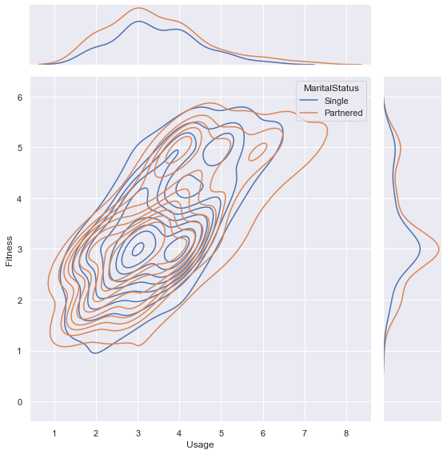

```python
sns.jointplot(data=cardio, x='Usage', y='Fitness', kind='kde', hue='MaritalStatus', height=8);
```

###### Observations:

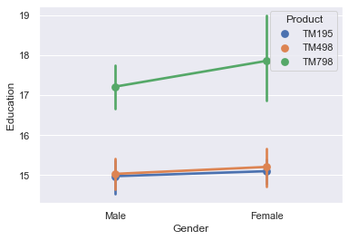

```python
sns.pointplot(y='Education', x='Gender', data=cardio, hue=cardio['Product']);
```

###### Observations:

- Model No. TM798 is preferred by Customers who have more no. of years of education(viz. > 16 years)
- Model No. TM195 & TM498 is preferred by Customers who have less no. of years of education(viz. education < 16 years)

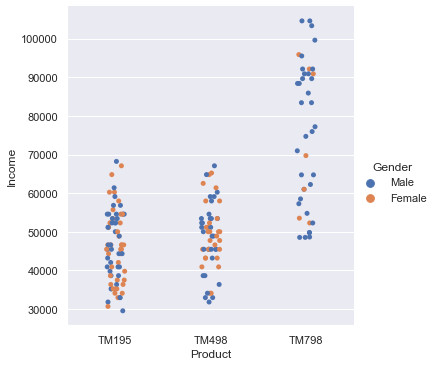

```python
sns.catplot(y='Income', x='Product', data=cardio, hue='Gender');
```

###### Observations:

- Model No. TM798 is more preferred by Customers whose Gender is 'Male' and have Income more than 45000
- Customers whose income is less than 70000 prefer the Model No. TM 195 & 498

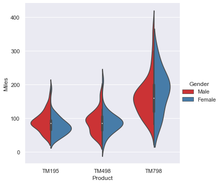

```python
sns.catplot(x="Product", y="Miles", hue="Gender",kind="violin", split=True, palette="Set1", data=cardio)
```

###### Observations:

- Both Gender Customers who are using Model No. TM798 have a longer run distribution of miles run viz. Around 100 to 300 miles
- Model No. 195 & 498 have a varied distribution of miles starting from least number of miles till around 200 miles

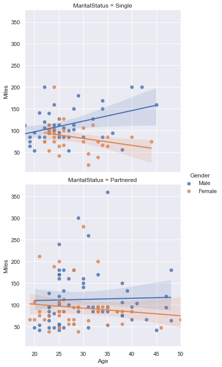

```python
sns.lmplot(x='Age',y='Miles',data=cardio,fit_reg=True,hue='Gender', row='MaritalStatus');
plt.show()
```

###### Observations:

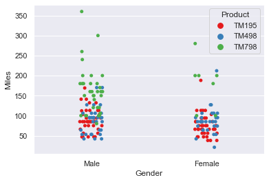

```python
sns.stripplot(x='Gender',y='Miles', hue='Product', jitter=True, data=cardio, palette='Set1')
```

###### Observations:

- Customers whose Gender is Male prefer to use Model No. TM 195 & TM498 whose Run Miles are less than 100.
- And Model. TM 798 for run Miles more than 150
- Customers whose Gender is Female prefer Model No. TM 195 & TM 498 over Model No. TM 798

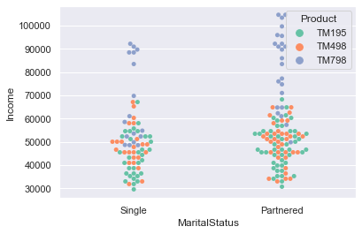

```python
sns.swarmplot(x='MaritalStatus',y='Income', hue='Product', data=cardio, palette='Set2')
```

###### Observations:

- More number of Customers in this datset are Partnered

### Plotting Multivariate Distributions

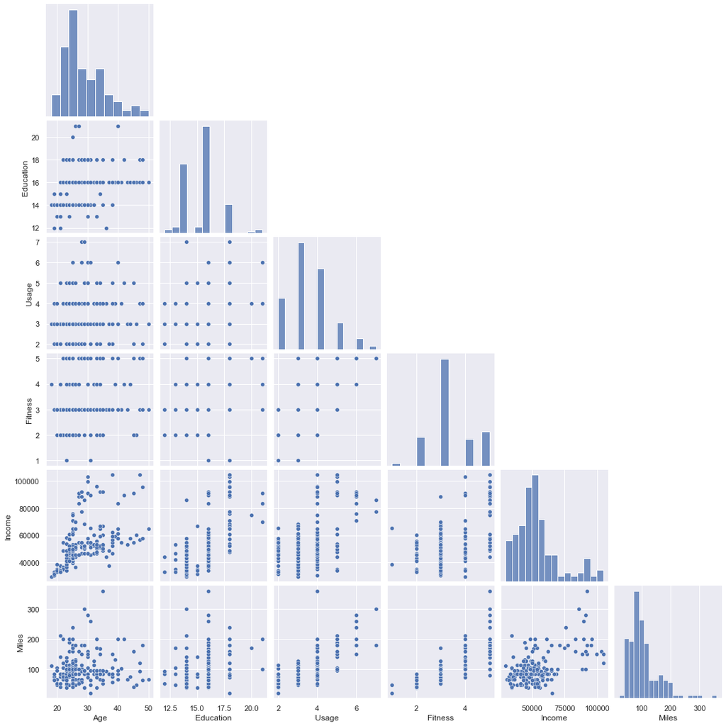

```python
sns.pairplot(data=cardio, corner=True);
```

###### Observations:

- The below pairplot gives visual representation between all the data features in the dataset
- The graphs which are histograms show the relationship between itself

#### Using inbuilt .Corr() method in Pandas to obtain precise information between all possible data features in dataset

```python
cardio.corr()
```

|  | Age | Education | Usage | Fitness | Income | Miles |
| --- | --- | --- | --- | --- | --- | --- |
| Age | 1.000000 | 0.280496 | 0.015064 | 0.061105 | 0.513414 | 0.036618 |
| Education | 0.280496 | 1.000000 | 0.395155 | 0.410581 | 0.625827 | 0.307284 |
| Usage | 0.015064 | 0.395155 | 1.000000 | 0.668606 | 0.519537 | 0.759130 |
| Fitness | 0.061105 | 0.410581 | 0.668606 | 1.000000 | 0.535005 | 0.785702 |
| Income | 0.513414 | 0.625827 | 0.519537 | 0.535005 | 1.000000 | 0.543473 |
| Miles | 0.036618 | 0.307284 | 0.759130 | 0.785702 | 0.543473 | 1.000000 |

###### Observations:

- As seen below the coorelations are calculated for all the numerical columns in the dataset

### Representing the above Correlation using heatmap function in seaborn

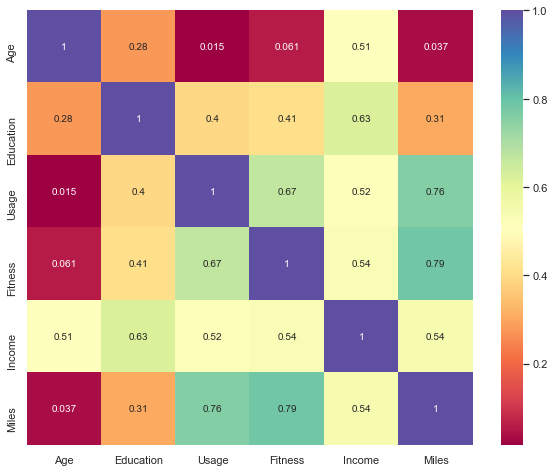

```python
plt.figure(figsize=(10,8));
sns.heatmap(cardio.corr(), annot=True, cmap='Spectral');
##Correlation > 0.6 are:
#Income & Education
#Fitness & Usage
#Fitness & Miles
#Miles & Usage
```

###### Observations:

- As expected Customers who have given a higher Fitness Score would plan to run more Miles
- Similarly Customers who run more number of Miles would also have more Usage of the treadmill
- Higher Education is linked to Higher Income

## Insights & Recommendations

#### Product Insights for TM195, TM498 & TM195

- Product TM195 is the most Popular model
- Highest Age of Customer usign Model TM195 is 50 years
- The mean miles run by Product TM195 is the lowest among other two products
- Lower Income Customers are inclined to buy Product TM195
- Average age of buying Product TM195 is the lowest
- Product TM798 is preferred by Customers who have more no. of years of education(viz. > 16 years)
- Product TM195 & TM498 is preferred by Customers who have less no. of years of education(viz. education < 16 years)
- The usage of Product TM195 is mostly 3-4 times a week
- TM195 are used by both Male & Female equally
- Higher Income Customers prefer to use TM798 over other Products
- Both Gender Customers who are using Model No. TM798 have a longer run distribution of miles run viz. Around 100 to 300 miles
- Product 195 & 498 have a varied distribution of miles starting from least number of miles till around 200 miles
- Product 798 is least sold product. Only 40 out of 180 Customers purchased it(i.e. 22.22%)
- Customers whose Gender is Male prefer to use Model No. TM 195 & TM498 whose Run Miles are less than 100. And Model. TM 798 for run Miles more than 150
- Customers whose Gender is Female prefer Model No. TM 195 & TM 498 over Model No. TM 798

#### General Data Insights(would be useful for Customer Segmentation and appropriate Advertising)

- Age Density in Dataset is 20-30 years
- Customers Education most distribution in dataset is 14-16 years
- Customers Incomemost distribution in dataset is 45000-60000
- Most of the Customers will run around 60-120 Miles
- Customers prefer to use Treadmill 3-4 times a week